# Criando o R Markdown da atividade 3

Nilson Berriel

03/10/2021

A espécie escolhida para esta atividade foi a *Metrodorea nigra* A.St.-Hil.. Uma espécie arbórea, decídua, endêmica do Brasil e de ocorrência registrada entre os estados do Maranhão e Paraná, contudo mais associada a Mata Atlântica. [^1]

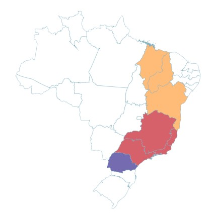

Distribuição da *M. nigra*

Vamos carregar os pacotes que serão utilizados: `tidyverse`, `rgbif`e `magrittr`.

A seguir, vamos utilizar a função `occ_data`, disponível no pacote `rgbif`, para selecionar os dados da *M. nigra* que serão utilizados.

```r
M.nigra_gbif <- occ_data(scientificName = "Metrodorea nigra",
                      hasCoordinate = TRUE,
                      hasGeospatialIssue=FALSE)
```

Agora vamos checar as dimenões dos dados encontrados:

```r
dim(M.nigra_gbif$data)
```

```
## [1] 405 120
```

Aqui vamos checar os campos de dados disponíveis para a espécie e assim selecionar as mais adequadas.

```r
M.nigra_gbif$data %>% names
```

```
##   [1] "key"                                "scientificName"
##   [3] "decimalLatitude"                    "decimalLongitude"
##   [5] "issues"                             "datasetKey"
##   [7] "publishingOrgKey"                   "installationKey"
##   [9] "publishingCountry"                  "protocol"
##  [11] "lastCrawled"                        "lastParsed"
##  [13] "crawlId"                            "hostingOrganizationKey"
##  [15] "basisOfRecord"                      "occurrenceStatus"
##  [17] "taxonKey"                           "kingdomKey"
##  [19] "phylumKey"                          "classKey"
##  [21] "orderKey"                           "familyKey"
##  [23] "genusKey"                           "speciesKey"
##  [25] "acceptedTaxonKey"                   "acceptedScientificName"
##  [27] "kingdom"                            "phylum"
##  [29] "order"                              "family"
```

[output cut: 45 more lines]

Desta forma iremos criar um novo objeto com as variáveis de maior interesse para a *M. nigra*.

```r
M.nigra_gbif1 <- M.nigra_gbif$data %>%
  dplyr::select(scientificName, acceptedScientificName, decimalLatitude, decimalLongitude,
                issues,elevation, basisOfRecord, rightsHolder,
                datasetName, recordedBy, locality, stateProvince,county, habitat)

M.nigra_gbif1
```

```
## # A tibble: 405 x 14
##    scientificName    acceptedScientifi~ decimalLatitude decimalLongitude issues
##    <chr>             <chr>                        <dbl>            <dbl> <chr>
##  1 Metrodorea nigra~ Metrodorea nigra ~          -23.1             -48.3 gass84~
##  2 Metrodorea nigra~ Metrodorea nigra ~          -23.7             -53.3 gass84~
##  3 Metrodorea nigra~ Metrodorea nigra ~          -23.0             -48.4 gass84~
##  4 Metrodorea nigra~ Metrodorea nigra ~          -22.8             -52.1 gass84~
##  5 Metrodorea nigra~ Metrodorea nigra ~          -22.7             -48.2 gass84~
##  6 Metrodorea nigra~ Metrodorea nigra ~          -22.7             -48.2 gass84~
##  7 Metrodorea nigra~ Metrodorea nigra ~           -5.06            -42.6 gass84~
##  8 Metrodorea nigra~ Metrodorea nigra ~          -23.4             -51.9 gass84~
##  9 Metrodorea nigra~ Metrodorea nigra ~           -5.02            -42.6 gass84~
## 10 Metrodorea nigra~ Metrodorea nigra ~           -5.02            -42.6 gass84~
## # ... with 395 more rows, and 9 more variables: elevation <dbl>,
## #   basisOfRecord <chr>, rightsHolder <chr>, datasetName <chr>,
## #   recordedBy <chr>, locality <chr>, stateProvince <chr>, county <chr>,
## #   habitat <chr>
```

Aqui podemos ver os resultados levantados para cada variável.

```r
lapply(M.nigra_gbif1, unique)
```

```
## $scientificName
## [1] "Metrodorea nigra A.St.-Hil."
## [2] "Metrodorea pubescens A.St.-Hil. & Tul."
## [3] "Metrodorea nigra var. brevifolia Engl."
## [4] "Metrodorea brevifolia (Engl. ex Mart.) Engl."
## [5] "Metrodorea selloana Engl."
##
## $acceptedScientificName
## [1] "Metrodorea nigra A.St.-Hil."
##
## $decimalLatitude
##   [1] -23.131389 -23.695056 -22.992222 -22.774140 -22.664722  -5.058333
##   [7] -23.384917  -5.020833 -21.400278 -21.402778 -22.754333 -23.416667
##  [13] -23.427043 -23.463278 -23.386075 -23.666667 -24.584444 -22.890278
##  [19] -22.299722 -24.534694 -24.534722 -10.833900 -22.414444 -22.245278
```

[output cut: 800 more lines]

Precisamos checar os problemas que são suspeitos de conter erros mais aparentes. Por se tratar de uma espécie arbórea, vamos inicialmente checar o habitat.

```r
M.nigra_gbif1 %>%
  distinct(habitat) %>%
  pull()
```

```
##  [1] NA
##  [2] "VegetaÃ§Ã£o arborea alta, com muitas epifitas, severamente atropizada."
##  [3] "Borda da mata."
##  [4] "Floresta."
##  [5] "Na trilha da mata."
##  [6] "Semi-deciduous forest"
##  [7] "Interior da mata"
##  [8] "No subosque da mata."
##  [9] "No interior da mata."
## [10] "Mata pluvial."
## [11] "Mata pluvial tropical, na encosta de morro.  Do interior da mata."
## [12] "Interior mata."
## [13] "Mata das margens do rio."
## [14] "Floresta higrÃ³fila de encosta."
## [15] "Roadside collections of mixed vegetation on a disturbed site. Red clay soil."
## [16] "Da beira do rio."
## [17] "Hillside vegetation by trail & little-disturbed hilltop forest.  Occasional by trail in forest."
## [18] "Mata HigrÃ³fila Sul Baiana."
## [19] "Da mata."
## [20] "Mata de galeria."
## [21] "Mata pluvial da bacia do rio."
## [22] "Forest on steep slope towards vÃ¡rzea land of rio."
## [23] "ColeÃ§ao de madeira."
## [24] "Margem da floresta."
## [25] "T. f. hilly country."
```

Agora, vamos checar as variáveis apresentadas, pois como vimos na função anterior, muitas das variáveis possuem **NA**’s em seus resultados. Assim, tentaremos filtrar alguns resultados para reduzir os erros, como espécimes que estejam em coleções.

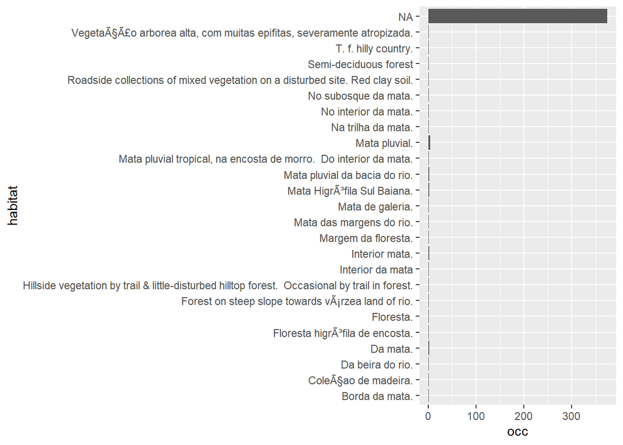

```r
M.nigra_gbif1 %>%
  group_by(habitat) %>%
  summarise(occ = length(scientificName)) %>%
  ggplot(aes(occ, y=habitat)) +
  geom_bar(stat = 'identity')
```

Como visto no gráfico acima, existe um grande número de **NA**’s para a variável habitat. Entretanto, uma das fontes de dados para a vaiável habitat consta como uma coleção de madeira. Vamos então checar e retirar e essa fonte.

```r
# fonte na coleção de madeira
M.nigra_gbif1 %>%
  filter(habitat %in% c("ColeÃ§ao de madeira.")) %>%
  distinct(habitat)
```

```
## # A tibble: 1 x 1
##   habitat
##   <chr>
## 1 ColeÃ§ao de madeira.
```

```r
M.nigra_gbif1 %>%
  filter(habitat %in% c("ColeÃ§ao de madeira."))
```

```
## # A tibble: 1 x 14
##   scientificName    acceptedScientific~ decimalLatitude decimalLongitude issues
##   <chr>             <chr>                         <dbl>            <dbl> <chr>
## 1 Metrodorea nigra~ Metrodorea nigra A~           -14.8            -39.2 cdroun~
## # ... with 9 more variables: elevation <dbl>, basisOfRecord <chr>,
## #   rightsHolder <chr>, datasetName <chr>, recordedBy <chr>, locality <chr>,
## #   stateProvince <chr>, county <chr>, habitat <chr>
```

```r
# filtrar todas do dataset suspeito
M.nigra_gbif_ok <- M.nigra_gbif1 %>%
  filter(!habitat %in% c("ColeÃ§ao de madeira."))
```

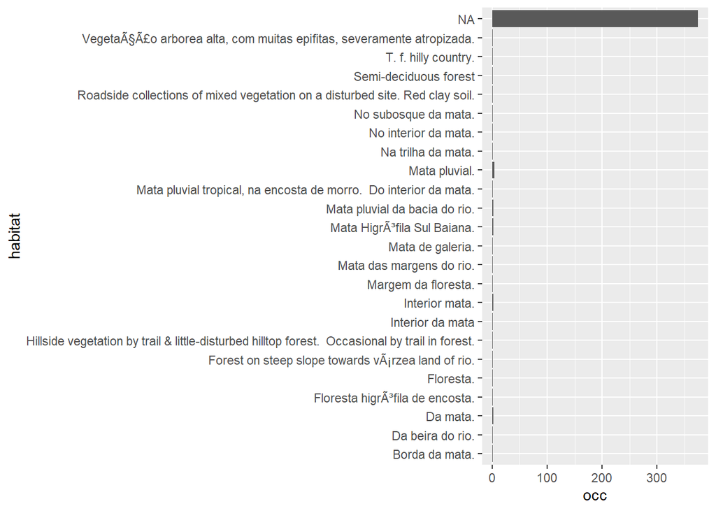

```r
#checando #rever o filtro q fiz, acredito q deu errado

M.nigra_gbif_ok %>%
  group_by(habitat) %>%
  summarise(occ = length(scientificName)) %>%
  ggplot(aes(occ, y=habitat)) +
  geom_bar(stat = 'identity')
```

Agora vamos fazer o procedimento para outras variáveis, como `stateProvince`, `elevation`. Que aparesentam valores que geram desconfiança, como: Rondônia (relacionado a uma coleção de madeira) e -4999.5 (que aparece mesmo em locais corretos de coleta).

```r
################ stateProvince ###################

M.nigra_gbif1 %>%
  filter(stateProvince %in% c("Rondônia")) %>%
  distinct(stateProvince)
```

```
## # A tibble: 1 x 1
##   stateProvince
##   <chr>
## 1 Rondônia
```

```r
M.nigra_gbif1 %>%
  filter(stateProvince %in% c("Rondônia"))
```

```
## # A tibble: 1 x 14
##   scientificName    acceptedScientifi~ decimalLatitude decimalLongitude issues
##   <chr>             <chr>                        <dbl>            <dbl> <chr>
## 1 Metrodorea nigra~ Metrodorea nigra ~           -10.2            -63.0 gass84,~
## # ... with 9 more variables: elevation <dbl>, basisOfRecord <chr>,
## #   rightsHolder <chr>, datasetName <chr>, recordedBy <chr>, locality <chr>,
## #   stateProvince <chr>, county <chr>, habitat <chr>
```

```r
M.nigra_gbif_ok <- M.nigra_gbif1 %>%
  filter(!stateProvince %in% c("Rondônia"))
##################################################

################ elevation #######################

M.nigra_gbif1 %>%
  filter(elevation %in% c("-4999.5")) %>%
  distinct(elevation)
```

```
## # A tibble: 1 x 1
##   elevation
##       <dbl>
## 1    -5000.
```

```r
M.nigra_gbif1 %>%
  filter(elevation %in% c("-4999.5"))
```

```
## # A tibble: 11 x 14
##    scientificName   acceptedScientif~ decimalLatitude decimalLongitude issues
##    <chr>            <chr>                       <dbl>            <dbl> <chr>
##  1 Metrodorea nigr~ Metrodorea nigra~          -23.8             -46.4 cdround,~
##  2 Metrodorea nigr~ Metrodorea nigra~          -23.8             -46.4 cdround,~
##  3 Metrodorea nigr~ Metrodorea nigra~          -23.8             -46.4 cdround,~
##  4 Metrodorea nigr~ Metrodorea nigra~          -19.4             -43.4 cdround,~
##  5 Metrodorea nigr~ Metrodorea nigra~          -17.1             -40.4 cdround,~
##  6 Metrodorea nigr~ Metrodorea nigra~          -23.0             -49.4 cdround,~
##  7 Metrodorea nigr~ Metrodorea nigra~          -16.9             -39.6 cdround,~
##  8 Metrodorea nigr~ Metrodorea nigra~          -21.3             -47.2 cdround,~
##  9 Metrodorea nigr~ Metrodorea nigra~           -9.25            -35.9 cdround,~
## 10 Metrodorea nigr~ Metrodorea nigra~          -22.4             -42.8 cdround,~
## 11 Metrodorea nigr~ Metrodorea nigra~           -3.83            -46.1 cdround,~
## # ... with 9 more variables: elevation <dbl>, basisOfRecord <chr>,
## #   rightsHolder <chr>, datasetName <chr>, recordedBy <chr>, locality <chr>,
## #   stateProvince <chr>, county <chr>, habitat <chr>
```

```r
M.nigra_gbif_ok <- M.nigra_gbif1 %>%
  filter(!elevation %in% c("-4999.5"))
##################################################
```

Agora serão carregados novos pacotes para a criação dos mapas. Os pacotes são: `ggmap`, `maps` e `mapdata`.

Por se tratar de uma espécie endêmica, vamos carregar somente o Brasil.

```r
brasil <- map_data('world',region="Brazil")
```

Criando com os pontos amostrados.

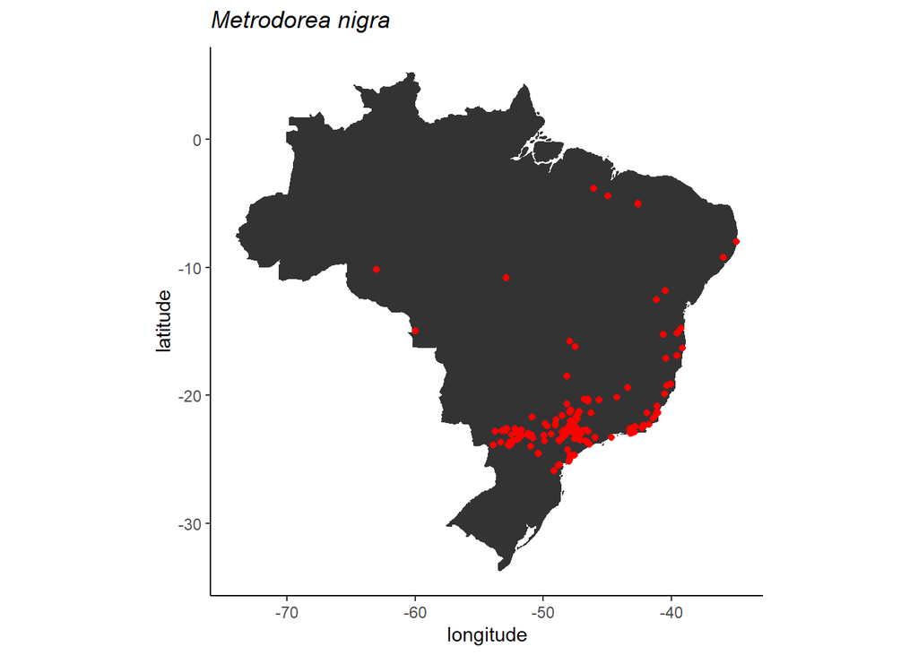

```r
ggplot() +
  geom_polygon(data = brasil, aes(x = long, y = lat, group = group)) +
  coord_fixed() +
  theme_classic() +
  geom_point(data = M.nigra_gbif_ok, aes(x = decimalLongitude, y = decimalLatitude), color = "red") +
  labs(x = "longitude", y = "latitude", title = expression(italic("Metrodorea nigra")))
```

Vamos utilizar agora os pacotes `CoordinateCleaner`e `biogeo`para a criação de um novo mapa, revelando agora os pontos que podem ser outlier.

Para isso utilizamentos a função `flag outlier`, do [prof. Cesar](https://github.com/cammcordeiro/ciencia_colab/blob/main/functions/aux_functions.R).

Selecionando as variáveis para aplicarmos a função `flag outlier`.

```r
marcados <- M.nigra_gbif$data %>%
  data.frame() %>%
  dplyr::select(scientificName, decimalLongitude, decimalLatitude, datasetName) %>%
  distinct() %>%
  flag_outlier(., "Metrodorea nigra A.St.-Hil.")
```

Criando o mapa com a função `flag outlier`.

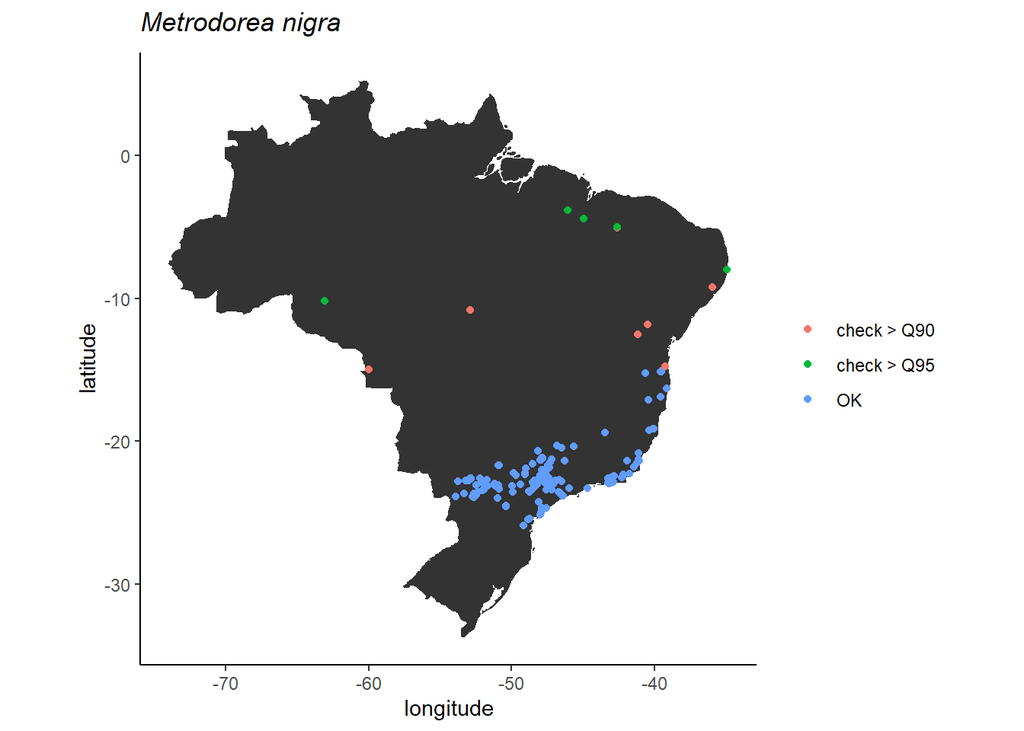

```r
ggplot() +
  geom_polygon(data = brasil, aes(x = long, y = lat, group = group)) +
  coord_fixed() +
  theme_classic() +
  geom_point(data = marcados,
             aes(x = decimalLongitude, y = decimalLatitude,
                 color = flag)) +
  theme(legend.title = element_blank()) +
  labs(x = "longitude", y = "latitude",
       title = expression(italic("Metrodorea nigra")))
```

[^1]: Pirani, J.R.; Groppo, M. 2020. Rutaceae in Flora do Brasil 2020. Jardim Botânico do Rio de Janeiro.Disponível em: http://reflora.jbrj.gov.br/reflora/floradobrasil/FB819. Acesso em: 03 out. 2021